# Week29 - d3treeR 2

July 22, 2015

## htmlwidgets News This Week

A **gallery is up** thanks to Ryan Hafen, but not “official”. As always, for all the newest and updated `htmlwidgets`, just do this [Github search](https://github.com/search?o=desc&q=htmlwidgets&s=indexed&type=Code).

## This Week’s Widget - `d3treeR` Again

d3treeR was released last week in the post [Week 28 | d3treeR](http://www.buildingwidgets.com/blog/2015/7/17/week-28-d3treer). We’ll do `d3treeR` again but we’ll make a version 2 `d3tree2` using the versions from Mike Bostock’s [Zoomable Treemaps](http://bost.ocks.org/mike/treemap/) and Zan Armstrong’s fork [Zoomable Treemaps with Color](https://gist.github.com/zanarmstrong/76d263bd36f312cb0f9f).

This `d3tree2` version should work much better when there are multiple levels of nesting or if you want a small in size `d3tree`. All it takes is one, so thanks so much for [@ignacio82](https://github.com/ignacio82) for the [motivation](https://github.com/timelyportfolio/d3treeR/issues/2).

## Quick Installation

`d3treeR` is not yet on CRAN and won’t be unless someone asks, so for now please install with `devtools::install_github`. If you installed last week, you’ll need to do this again.

```r
devtools::install_github("timelyportfolio/d3treeR")
```

## Examples

Let’s look at the differences between `d3tree` and `d3tree2` in the examples below. We’ll use the same examples as last week.

### `treemap` as data

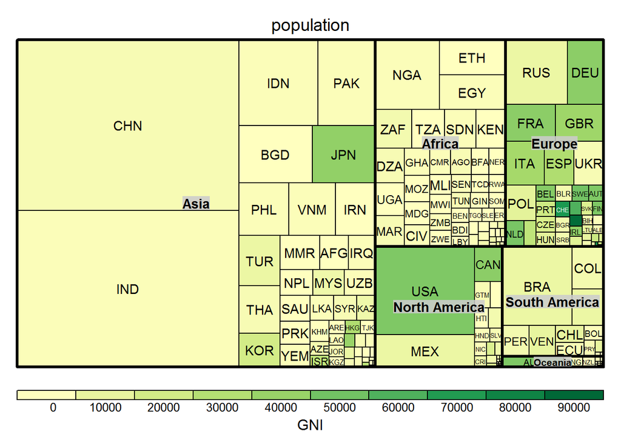

[interactive chart not shown]

```r
# devtools::install_github("timelyportfolio/d3treeR")
library(treemap)
library(d3treeR)

# first example from ?treemap

data(GNI2010)

tm <-  treemap(
   GNI2010,
   index=c("continent", "iso3"),
   vSize="population",
   vColor="GNI",
   type="value"
 )


d3tree( tm,rootname = "World" )

d3tree2( tm,rootname = "World" )
```

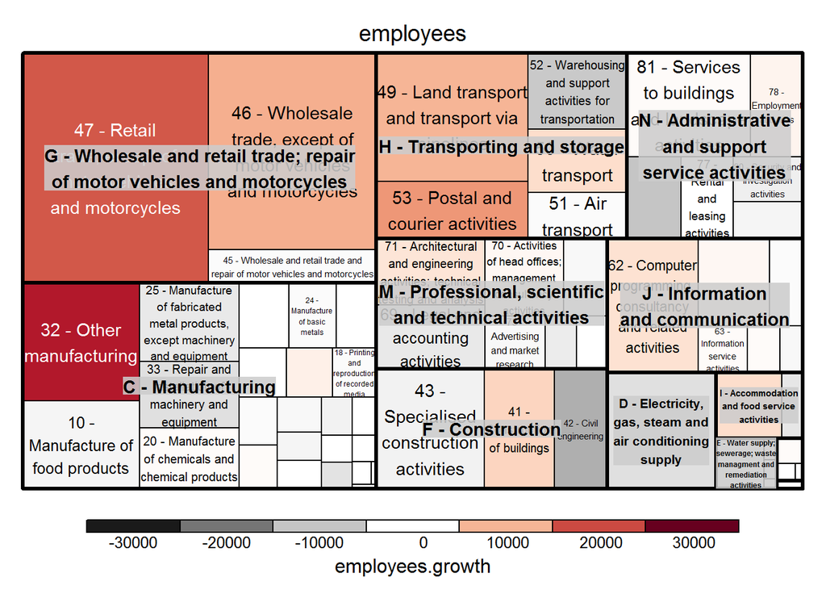

[interactive chart not shown]

```r
# devtools::install_github("timelyportfolio/d3treeR")
library(treemap)
library(d3treeR)

# last example from ?treemap

data(business)
business$employees.growth <- business$employees - business$employees.prev

tm <- # Brewer's Red-White-Grey palette reversed with predefined range
  treemap(business,
          index=c("NACE1", "NACE2"),
          vSize="employees",
          vColor="employees.growth",
          type="value",
          palette="-RdGy",
          range=c(-30000,30000))

d3tree( tm, rootname = "World" )

d3tree2( tm, rootname = "World" )
```

### `JSON` as data

We can use `JSON` or lists from `R` to provide our hierarchy. Let’s use the ubiquitous `flare.json`.

```r
library(treemap)
library(d3treeR)

  # with flare.json from Mike Bostock

d3tree(
  "http://bl.ocks.org/mbostock/raw/4063582/raw/flare.json"
  ,id = "name"
  ,height = 520
  ,width = 620
)

d3tree2(
  "http://bl.ocks.org/mbostock/raw/4063582/raw/flare.json"
  ,id = "name"
  ,height = 520
  ,width = 620
)
```

[interactive chart not shown]

## Thanks

Thanks so much to Martijn Tennekes, Edwin de Jonge, Mike Bostock, Bill White, and Zan Armstrong.

As always, thanks to

- Ramnath Vaidyanathan and RStudio for `htmlwidgets`
- all the contributors to `R` and `JavaScript`